# Math 120 Week 06

Prof Miller

04 April, 2021

# Wed March 31

Simulation for the dice distribution.

```r
mean(sample(1:6, 1000, replace = TRUE))
```

```
## [1] 3.47
```

Idea: take MANY samples, find their means, make histogram.

20000 Dice Rolls (n=1)

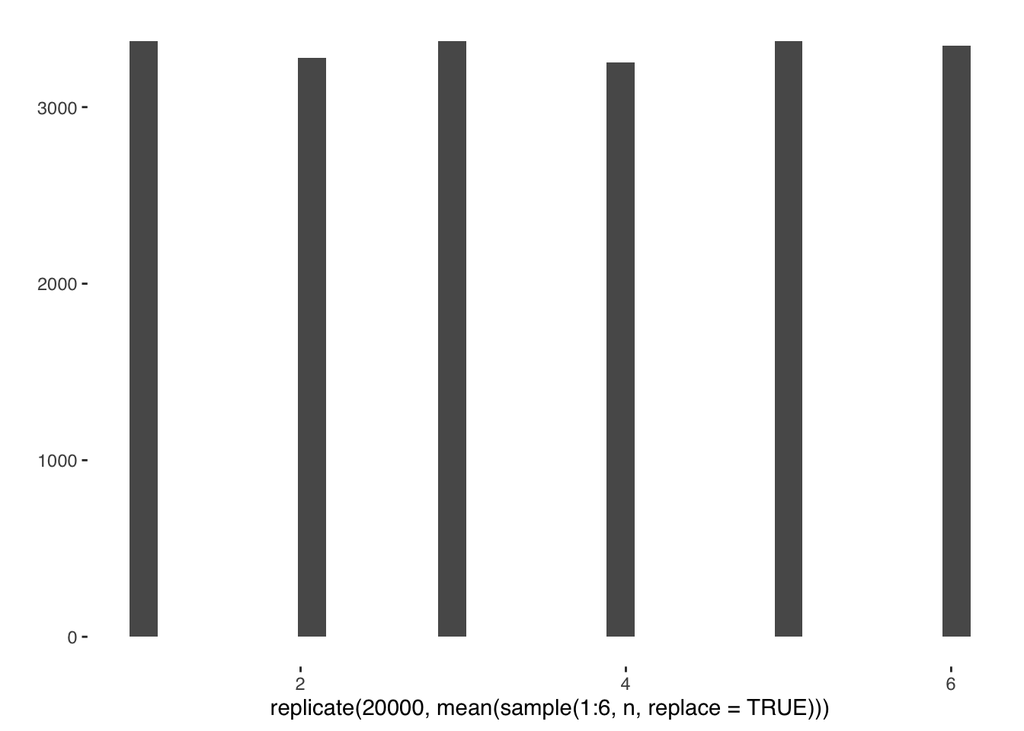

```r
n=1
qplot(replicate(20000, mean(sample(1:6, n, replace=TRUE))))
```

Thousands of means (xbar), n=2 dice:

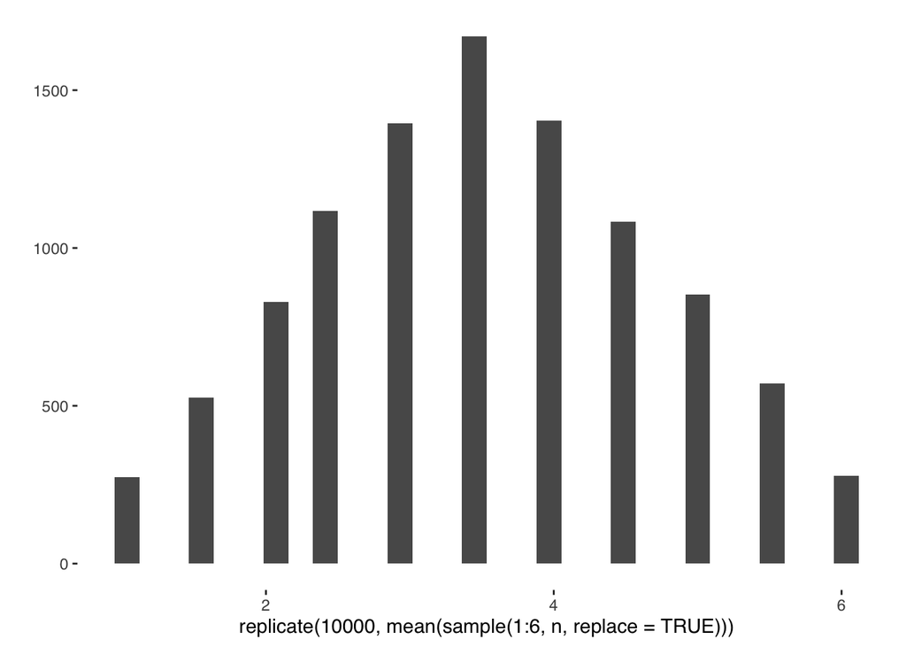

```r
n=2
qplot(replicate(10000, mean(sample(1:6, n, replace=TRUE))))
```

Thousands of means (xbar), n=5 dice

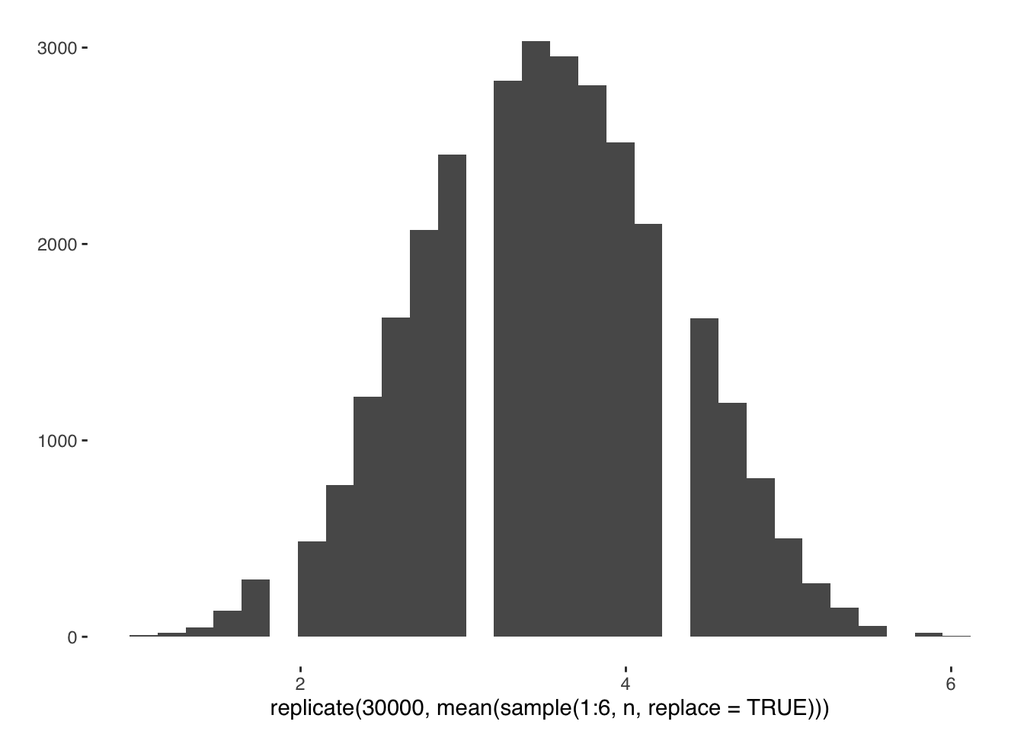

```r
n=5
qplot(replicate(30000, mean(sample(1:6, n, replace=TRUE))),bins=30)
```

Thousands of means, n=30 dice

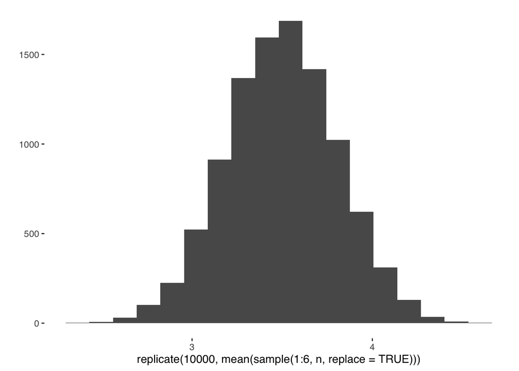

```r
n=30
qplot(replicate(10000, mean(sample(1:6, n, replace=TRUE))),bins=18)
```

Woah! Looks familiar!

Summary:

- When looking at sample averages (xbar), smooshed towards the center. Less likely to get very small xbar or very xbar.
- As n (sample size) gets larger and larger, the sampling distribution for xbar gets closer and closer to a normal distribution! Woah!
- We know the probability dist for xbar. Ie, we can say how likely or unlikely SAMPLE MEANS are!

Summary:

Know the shape: normal.

```
z = (x-mean)/stdev
```

Center: the mean stays the same!

- the expected value for xbar is the same as the expected value for x

Spread: stdev for xbar is

```
s_x / sqrt(n)

= stdev for original population / sqrt of sample size
```

Note: as n gets big, s_x/n gets small! Bigger samples have less variation!

### Ex 1:

Height for adult men is normal, mean=69“, stdev = 2.7”. What’s the probability that a randomly selected man is at least 70" tall?

```
z = (70-69)/2.7
```

```r
(70-69)/2.7
```

```
## [1] 0.3703704
```

Look up z = 0.37

P(X>70) =

```r
1-0.6443
```

```
## [1] 0.3557
```

About 35.57% of men are at least 70" tall.

### Ex 2:

Suppose we take a sample of 4 men and calculate their average height. What’s the probability that xbar is at least 70"?

Ie, P( xbar >= 70)

mean: stays the same. mean for xbar = 69"

spread: smaller. spread for sbar = 2.7/sqrt(4) = 1.35

[output not shown]

```r
1-.9115
```

```
## [1] 0.0885
```

### Ex 3)

If we take a sample of n=30 men what’s the prob that their mean height is at least 70"?

mean: 69 (doesn’t change) stdev: 2.7/sqrt(30)

```
  P(xbar >= 70) = P(Z > (70-69)/ ( 2.7/sqrt(30) )   )
```

```r
(70-69)/( 2.7/sqrt(30) )
```

```
## [1] 2.028602
```

```
                = P(Z > 2.03) = 1-.9788
```

```r
1-.9788
```

```
## [1] 0.0212
```

Observations:

### Ex:

The life span of a brand of lightbulb has mean of 10,000 hours with stdev 500. If we take a sample of 60 lightbulbs, what are the cutoffs for the middle 70% most likely sample averages?

Look up area = .15 in table: z = +/- 1.04

```
 z = (obs - mean)/stdev

 z = (xbar - mean)/(stdev/sqrt(n))
```

Low:

```r
-1.04*(500/sqrt(60))+10000
```

```
## [1] 9932.868
```

hi:

```r
1.04*(500/sqrt(60))+10000
```

```
## [1] 10067.13
```

The middle 70% most common sample means are between 9932.9, 10067.1.

# Friday April 2

Last time: samp dist for xbar.

Idea: find probability of a particular sample mean.

Center: stays the same

```
 mu_xbar = mu_x
```

Think: “the mean of the mean is the mean”.

Spread: gets smaller with n

```
 sigma_xbar = sigma/sqrt(n)
```

Shape:

- If X (original pop) is normal, then xbar (samp dist) is normal no matter what n is.
- CLT: As long as n is large (n>=30), then xbar is normal no matter what original population we sample from!! Holy cow!

### Ex:

Giraffe height is normal with mean 18’, stdev 2.5’. If we take sample of 5 giraffes, what’s the prob their mean height is at least 19’ tall?

mu_x = 18 (population mean) sigma_x = 2.5 (population stdev)

n=5

Find: P(xbar >= 19)

Q: Can we use Z table? Is xbar normal? Since giraffe height is normal, xbar is normal even for small n.

Dist for xbar:

mu_xbar = 18 sigma_xbar = 2.5/sqrt(5)

z:

```r
(19-18)/(2.5/sqrt(5))
```

```
## [1] 0.8944272
```

Area on right:

```r
1-.8133
```

```
## [1] 0.1867
```

There’s about an 18.67% chance of observing such a sample mean.

## Proportions

Idea: xbar is the statistic for quant data (numbers) phat is the statistic for qualitative data (categories)

Sampling Dist for phat:

Center: doesn’t change

```
 mu_phat = p
```

Spread: decreases with n

```
 sigma_phat = sqrt( p(1-p)/n )
```

Shape: CLT works for phat also!

```
 If n is "large enough", phat follows a normal dist no matter what.
```

### Ex)

At DU, 19% of students are international students.

If we take a sample of 100 DU students, what’s the probability that at least a quarter (25%) of them are international?

```
p = .19

n = 100
```

Need:

```
P(phat > .25)
```

Q: can we use Z table? Is phat normal?

```
Need:  np>=10  and n(1-p)>=10
```

```r
100*.19
```

```
## [1] 19
```

```r
100*(1-.19)
```

```
## [1] 81
```

YES! CLT IS SATISFIED! UZE Z TABLE!

Get z-score:

```
z = (obs - exp)/spread

  = (.25 - .19)/sqrt( .19 * (1-.19) / 100 )
```

```r
(.25 - .19)/sqrt( .19 * (1-.19) / 100 )
```

```
## [1] 1.529438
```

z = 1.53

On table: area to left = .9370

P(phat >= .25) =

```r
1-.9370
```

```
## [1] 0.063
```

There’s about a 6.3% chance of observing such a sample proportion.

### Ex)

At DU, 77% of students are from out-of-state.

In a sample of 60 students, what’s the probability that at least half are from out of state?

```
p = .77
n = 60
```

Can we use z?

```r
60*.77
```

```
## [1] 46.2
```

```r
60*(1-.77)
```

```
## [1] 13.8
```

Find z for phat = .5

```
(.5 - .77)/sqrt( .77 * (1-.77) / 60)
```

```r
(.5 - .77)/sqrt( .77 * (1-.77) / 60)
```

```
## [1] -4.969699
```

P(Z > -4.97) = almost 1

It’s nearly certain that more than half of students in the sample are out-of-state.